# Coffee Analysis Report

Ghadi K

19-10-2020

This report is done on the coffee ratings dataset it contains reviews of 1312 arabica and 28 robusta coffee beans from the Coffee Quality Institute trained reviewers. The features include and used in this report are Aroma grade one of the quality measures and Country of Origin from farm metadata that tells us where the bean came from.

After read and explore dataset I was wondering if there is relationship between the coffee bean origin country and coffee aroma.

## Report Question

So in this report, I will try to answer this question; Does Coffee Bean Origin Affect Coffee Aroma?

# Descriptive Statistics

The table shows the means and standard deviation of Aroma for each Country of origin. so we can understand the relationship better.

|  | Country.of.Origin | n | Average | SD |
| --- | --- | --- | --- | --- |
| 1 | Brazil | 132 | 7.55310606060606 | 0.327134523245203 |
| 2 | China | 16 | 7.64125 | 0.320767309223784 |
| 3 | Colombia | 183 | 7.65306010928962 | 0.268421170808954 |
| 4 | Costa Rica | 51 | 7.67137254901961 | 0.310290313144598 |
| 5 | El Salvador | 21 | 7.6747619047619 | 0.276778233385847 |
| 6 | Ethiopia | 44 | 7.89636363636364 | 0.354053542850617 |
| 7 | Guatemala | 181 | 7.54486187845304 | 0.310296646121465 |
| 8 | Honduras | 53 | 7.29245283018868 | 1.0549898024669 |
| 9 | India | 14 | 7.69785714285714 | 0.171741244158341 |
| 10 | Indonesia | 20 | 7.649 | 0.331486286133736 |

[output cut: 9 more lines]

# Data Visualization

Here I visualize data to see a pattern and trends it is easier to understand these thing after visualize data set .

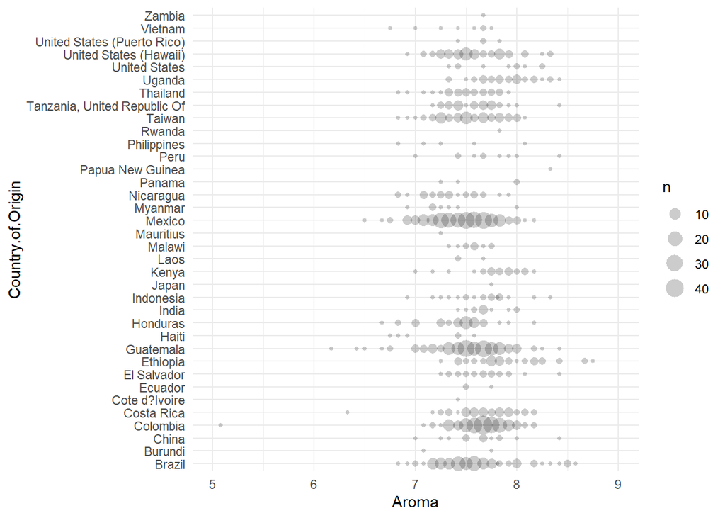

# The ANOVA summary

I apply ANOVA to determine if there is really a relation between Country of origin and aroma. this summary can help determine if Country of origin really affect coffee Aroma.

Analysis of Variance Model

|  | Df | Sum Sq | Mean Sq | F value | Pr(>F) |
| --- | --- | --- | --- | --- | --- |
| **Country.of.Origin** | 35 | 24.79 | 0.7084 | 5.581 | 3.568e-22 |
| **Residuals** | 1302 | 165.3 | 0.1269 | NA | NA |

After applying the ANOVA model it became clear that is reasonable to say that country of origin affects the coffee aroma. And the aroma change depending on the country of origin.

## Answer for Report Question?

Yes, the country of origin let the coffee have a different Aroma.